# Dipper Model with `dCJS` Distribution

### Revisting the Dipper Model

Now we’re going to revisit the dipper model, but this time use the `dCJS` distribution from the `nimbleEcology` package to speed things up.

### The `dCJS` distribution in `nimbleEcology`

There are four versions of the `dCJS` distribution in `nimbleEcology`. These differ only in whether survival probability and/or capture probability are time-dependent or time-independent, yielding four combinations:

- `dCJS_ss`: Both survival and capture probabilities are time-independent (scalars)
- `dCJS_sv`: Survival is time-independent (scalar). Capture probability is time-dependent (vector)
- `dCJS_vs`: Survival is time-dependent (vector). Capture probability is time-independent (scalar)
- `dCJS_vv`: Both survival and capture probabilities are time-dependent (vectors)

So, for updating our first version of the dipper model, we’ll want the first one (`dCJS_ss`), where both survival and detection are time-independent.

The usage of this distribution is as follows:

`y[i, first[i]:T] ~ dCJS_ss(probSurvive = phi, probCapture = p, len = length[i])`

Note the following:

- `y[i, 1:T]` is a vector of capture history.
- `phi` and `p` are the (constant) probabilities of survival and detection.
- `length` is a new variable (which we’ll need to create), which gives the length of the capture history for each individual.

### Implementation of the `dCJS_ss` distribution

The `dCJS_ss` distribution is implemented as a `nimbleFunction` (we’ll talk more about these later).

```r
dCJS_ss <- nimbleFunction(
    run = function(
        x = double(1), probSurvive = double(), probCapture = double(),
        len = double(0, default = 0), log = integer(0, default = 0)) {
        ## Note the calculations used here are actually in hidden Markov model form.
        probAliveGivenHistory <- 1
        ## logProbData will be the final answer
        logProbData <- 0
        lenX <- length(x)
        for (t in 1:lenX) {
            ## probAlive is P(Alive(t) | x(1)...x(t-1))
            ## probAliveGivenHistory is (Alive(t-1) | x(1)...x(t-1))
            probAlive <- probAliveGivenHistory * probSurvive
            if (!is.na(x[t])) {
                if (x[t] == 1) {
                    ## ProbThisObs = P(x(t) | x(1)...x(t-1))
                    probThisObs <- probAlive * probCapture
                    probAliveGivenHistory <- 1
                } else {
                    probAliveNotSeen <- probAlive * (1 - probCapture)
                    probThisObs <- probAliveNotSeen + (1 - probAlive)
                    probAliveGivenHistory <- probAliveNotSeen / probThisObs
                }
            }
            logProbData <- logProbData + log(probThisObs)
        }
        if (log) return(logProbData)
        return(exp(logProbData))
        returnType(double(0))
    }
)
```

### Dipper Data

In case you need it again, you can [download the dipper data here](https://danielturek.github.io/nimble-cefe-2019/data/dipper_data.Rdata).

### Exercise: Implementing the `dCJS` dipper model

Let’s modify our dipper code, to use the `dCJS_ss` distribution.

The updated model will no longer contain any `x[i, t]` latent states.

### Results

Here are the results I got for this `dCJS` version of the dipper model:

```r
round(samplesSummary(samplesCJS), 2)
```

```
##     Mean Median St.Dev. 95%CI_low 95%CI_upp
## p   0.90   0.90    0.03      0.83      0.95
## phi 0.56   0.56    0.03      0.51      0.61
```

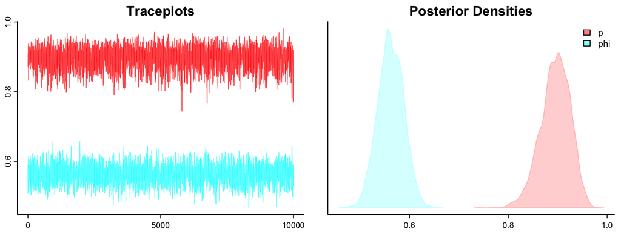

```r
library(basicMCMCplots)

basicMCMCplots::samplesPlot(samplesCJS, c('p', 'phi'))
```

### Compare results to original latent state model

It’s good to compare these results from the `dCJS` model with the original results, from the latent state version of the model.

Samples from the latent state version are called `samplesOrig`, and from the `dCJS` model are called `samplesCJS`.

We’ll use `chainsPlot`, and also `chainsSummary` to compare these samples.

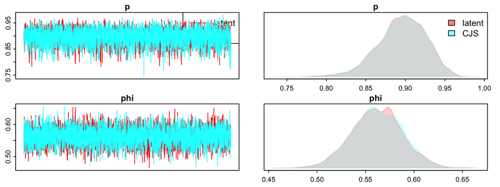

```r
library(basicMCMCplots)

samplesList <- list(latent = samplesOrig,
                    CJS    = samplesCJS)

basicMCMCplots::chainsPlot(samplesList)
```

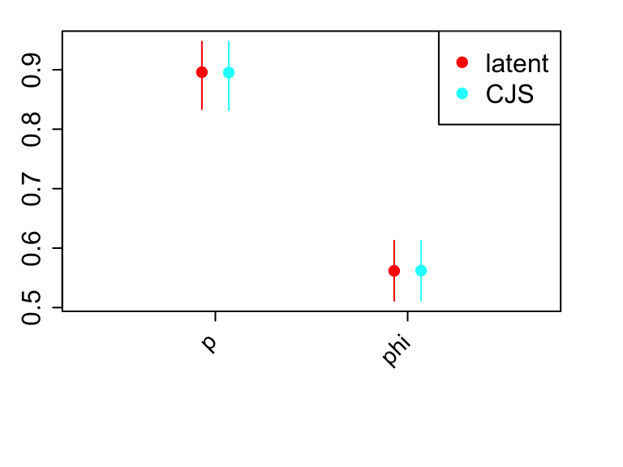

```r
chainsSummary(samplesList, jitter = 0.2, buffer.left=.7, buffer.right=.7)
```